# Maryland Operating Budget Analysis (FY2017-2026)

## Executive Summary

This notebook provides a comprehensive exploratory data analysis of Maryland's Operating Budget across fiscal years 2017-2026. The analysis examines budget allocation patterns across state agencies, funding sources, and program categories.

**Data Source:** Maryland Department of Budget and Management (DBM)  
**Dataset:** Operating Budget - Funding Source (opendata.maryland.gov)  
**Note:** All budget values are in actual U.S. dollars, not millions or billions.

```python
import os
import pandas as pd
import numpy as np
import seaborn as sns
import matplotlib.pyplot as plt
import dotenv
import mssql_python
import warnings

warnings.filterwarnings("ignore", message="pandas only supports SQLAlchemy connectable")

# Set plotting style
sns.set_palette("husl")
plt.rcParams['figure.dpi'] = 100

# Helper function to format large numbers
def format_currency(value):
    """Format currency values for better readability"""
    if value >= 1_000_000_000:
        return f"${value/1_000_000_000:.2f}B"
    elif value >= 1_000_000:
        return f"${value/1_000_000:.2f}M"
    elif value >= 1_000:
        return f"${value/1_000:.2f}K"
    else:
        return f"${value:.2f}"

# Load environment variables
dotenv.load_dotenv()
SQL_CONNECTION_STRING = os.getenv("SQL_CONNECTION_STRING")

if not SQL_CONNECTION_STRING:
    raise ValueError("SQL_CONNECTION_STRING not found in environment variables. Please add it to your .env file.")

# Connect and load 9-column subset from SQL
SQL_QUERY = """
SELECT
    fiscal_year,
    agency_name,
    program_name,
    unit_name,
    category_title,
    fund_type_name,
    fund_source_name,
    description,
    budget
FROM dbo.OperatingBudget
WHERE budget IS NOT NULL AND budget > 0
"""

print("📊 Loading Maryland Operating Budget Data...\n")

try:
    conn = mssql_python.connect(SQL_CONNECTION_STRING)
    df = pd.read_sql(SQL_QUERY, conn)
    conn.close()

    print(f"✓ Data loaded successfully: {len(df):,} rows × {len(df.columns)} columns")
    print(f"✓ Fiscal years covered: FY{df['fiscal_year'].min():.0f} to FY{df['fiscal_year'].max():.0f}")
    print(f"✓ Total budget amount: {format_currency(df['budget'].sum())}")
    print(f"✓ Number of agencies: {df['agency_name'].nunique()}")

except Exception as e:
    print(f"✗ Error loading data: {e}")
    raise

# Verify all required columns are present
required_cols = ['fiscal_year', 'agency_name', 'program_name', 'unit_name', 'category_title',
                 'fund_type_name', 'fund_source_name', 'description', 'budget']
missing_cols = [col for col in required_cols if col not in df.columns]
if missing_cols:
    raise ValueError(f"Missing required columns: {missing_cols}")

print(f"✓ All {len(required_cols)} required columns validated\n")
print("="*80)
```

[output not shown]

## 1. Data Loading & Setup

```python
# Basic Data Overview
print("First 5 rows:")
print(df.head())

print("\n" + "="*80)
print("Data Info:")
print(df.info())

print("\n" + "="*80)
print("Missing Values:")
missing = df.isnull().sum()
missing_pct = (df.isnull().sum() / len(df)) * 100
missing_df = pd.DataFrame({"Missing Count": missing, "Missing %": missing_pct})
print(missing_df[missing_df["Missing Count"] > 0])
```

```
First 5 rows:
   fiscal_year             agency_name  \
0         2017  Department of Commerce
1         2017  Department of Commerce
2         2017  Department of Commerce
3         2017  Department of Commerce
4         2017  Department of Commerce

                                        program_name  \
0  Small, Minority, and Women-Owned Business Inve...
1                     Office of the Attorney General
2  Maryland Industrial Development Financing Auth...
3             Office of Military and Federal Affairs
4                     Office of Business Development

                                           unit_name category_title  \
0  Division of Business and Industry Sector Devel...          Other
1                            Office of the Secretary          Other
2  Division of Business and Industry Sector Devel...          Other
3                            Office of the Secretary          Other
4  Division of Business and Industry Sector Devel...          Other

  fund_type_name                                   fund_source_name  \
0  Special Funds  Small, Minority and Women-Owned Business Inves...
1  Special Funds  Maryland Economic Development Assistance Autho...
2  Federal Funds             State Small Business Credit Initiative
3  General Funds                                      General Funds
4  Special Funds  Maryland Small Business Development Financing ...

                                         description      budget
0  This program receives 1.5% from the proceeds o...  11348644.0
1  The Office of the Attorney General provides le...    827890.0
2  This program was established to promote signif...   7298532.0
3  This office serves as the State's liaison to M...    926833.0
4  The Office of Business Development (OBD) focus...     95835.0

================================================================================
Data Info:
<class 'pandas.core.frame.DataFrame'>
RangeIndex: 23698 entries, 0 to 23697
Data columns (total 9 columns):
 #   Column            Non-Null Count  Dtype
---  ------            --------------  -----
 0   fiscal_year       23698 non-null  int64
 1   agency_name       23698 non-null  object
 2   program_name      23698 non-null  object
 3   unit_name         23698 non-null  object
 4   category_title    23698 non-null  object
 5   fund_type_name    23698 non-null  object
 6   fund_source_name  23698 non-null  object
 7   description       23697 non-null  object
 8   budget            23698 non-null  float64
dtypes: float64(1), int64(1), object(7)
memory usage: 1.6+ MB
None

================================================================================
Missing Values:
             Missing Count  Missing %
description              1    0.00422
```

## 2. Data Overview & Quality Check

```python
# Statistical Summary - Budget Focus
print("Budget Statistics Summary:\n")

# Create a clean table of statistics with readable formatting
stats_data = {
    'Metric': [
        'Total Budget',
        'Average Budget',
        'Median Budget',
        'Std Deviation',
        'Min Budget',
        'Max Budget',
        '25th Percentile',
        '75th Percentile'
    ],
    'Value': [
        format_currency(df['budget'].sum()),
        format_currency(df['budget'].mean()),
        format_currency(df['budget'].median()),
        format_currency(df['budget'].std()),
        format_currency(df['budget'].min()),
        format_currency(df['budget'].max()),
        format_currency(df['budget'].quantile(0.25)),
        format_currency(df['budget'].quantile(0.75))
    ]
}

# Print formatted table
print(f"{'Metric':<20} {'Value':>15}")
print("-" * 37)
for metric, value in zip(stats_data['Metric'], stats_data['Value']):
    print(f"{metric:<20} {value:>15}")

print("\n" + "="*80)
```

```
Budget Statistics Summary:

Metric                         Value
-------------------------------------
Total Budget                $503.54B
Average Budget               $21.25M
Median Budget               $525.00K
Std Deviation               $189.33M
Min Budget                     $1.00
Max Budget                    $7.83B
25th Percentile              $63.69K
75th Percentile               $3.80M

================================================================================
```

## 3. Budget Statistics

```
Records by Fiscal Year:

  FY2017: 2,285 records
  FY2018: 2,265 records
  FY2019: 2,294 records
  FY2020: 2,377 records
  FY2021: 2,464 records
  FY2022: 2,461 records
  FY2023: 2,450 records
  FY2024: 2,396 records
  FY2025: 2,372 records
  FY2026: 2,334 records

  Total: 23,698 records
  Range: FY2017 - FY2026
```

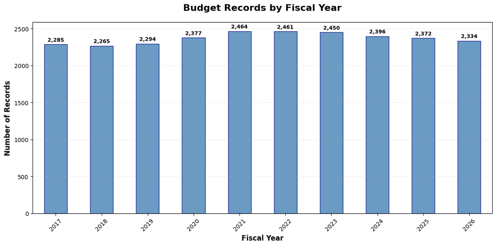

```
📊 Key Insights:
  • Year with fewest records: FY2018 with 2,265 records
  • Year with most records: FY2021 with 2,464 records
  • Average records per year: 2,370

================================================================================
```

```python
# Fiscal Year Distribution
print("Records by Fiscal Year:\n")
fy_counts = df['fiscal_year'].value_counts().sort_index()

for year, count in fy_counts.items():
    print(f"  FY{int(year):4d}: {count:,} records")

print(f"\n  Total: {fy_counts.sum():,} records")
print(f"  Range: FY{int(df['fiscal_year'].min())} - FY{int(df['fiscal_year'].max())}")

# Plot fiscal year distribution
fig, ax = plt.subplots(figsize=(12, 6))
fy_counts.plot(kind='bar', ax=ax, color='steelblue', edgecolor='navy', alpha=0.8)
ax.set_title('Budget Records by Fiscal Year', fontsize=16, fontweight='bold', pad=20)
ax.set_xlabel('Fiscal Year', fontsize=12, fontweight='bold')
ax.set_ylabel('Number of Records', fontsize=12, fontweight='bold')
ax.grid(axis='y', alpha=0.3, linestyle='--')

# Add value labels on bars
for i, v in enumerate(fy_counts):
    ax.text(i, v + fy_counts.max()*0.01, f'{v:,}', ha='center', va='bottom', fontsize=9, fontweight='bold')

ax.tick_params(axis='x', rotation=45)
plt.tight_layout()
plt.show()

print("\n📊 Key Insights:")
print(f"  • Year with fewest records: FY{int(fy_counts.idxmin())} with {fy_counts.min():,} records")
print(f"  • Year with most records: FY{int(fy_counts.idxmax())} with {fy_counts.max():,} records")
print(f"  • Average records per year: {fy_counts.mean():,.0f}")

print("\n" + "="*80)
```

## 4. Temporal Analysis

### 4.1 Fiscal Year Distribution

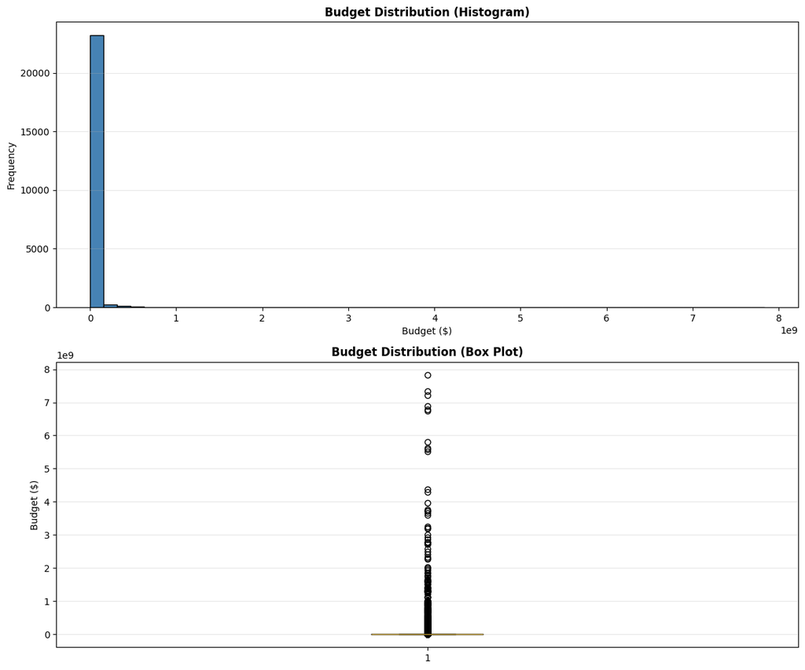

```python
# Budget Distribution
fig, axes = plt.subplots(2, 1, figsize=(12, 10))

# Histogram
axes[0].hist(df['budget'], bins=50, color='steelblue', edgecolor='black')
axes[0].set_title('Budget Distribution (Histogram)', fontsize=12, fontweight='bold')
axes[0].set_xlabel('Budget ($)')
axes[0].set_ylabel('Frequency')
axes[0].grid(axis='y', alpha=0.3)

# Box plot
axes[1].boxplot(df['budget'], vert=True)
axes[1].set_title('Budget Distribution (Box Plot)', fontsize=12, fontweight='bold')
axes[1].set_ylabel('Budget ($)')
axes[1].grid(axis='y', alpha=0.3)

plt.tight_layout()
plt.show()
```

### 4.2 Budget Value Distribution

```
Top 10 Agencies by Total Budget:

   1. Maryland Department of Health                        $176.04B
   2. State Department of Education                         $97.81B
   3. Department of Transportation                          $55.15B
   4. Department of Human Services                          $33.93B
   5. Support for State Operated Institutions of Higher Education    $20.06B
   6. Department of Public Safety and Correctional Services    $15.40B
   7. Public Debt                                           $13.50B
   8. Department of Housing and Community Development        $7.86B
   9. State Reserve Fund                                     $7.47B
  10. Maryland Higher Education Commission                   $6.65B
```

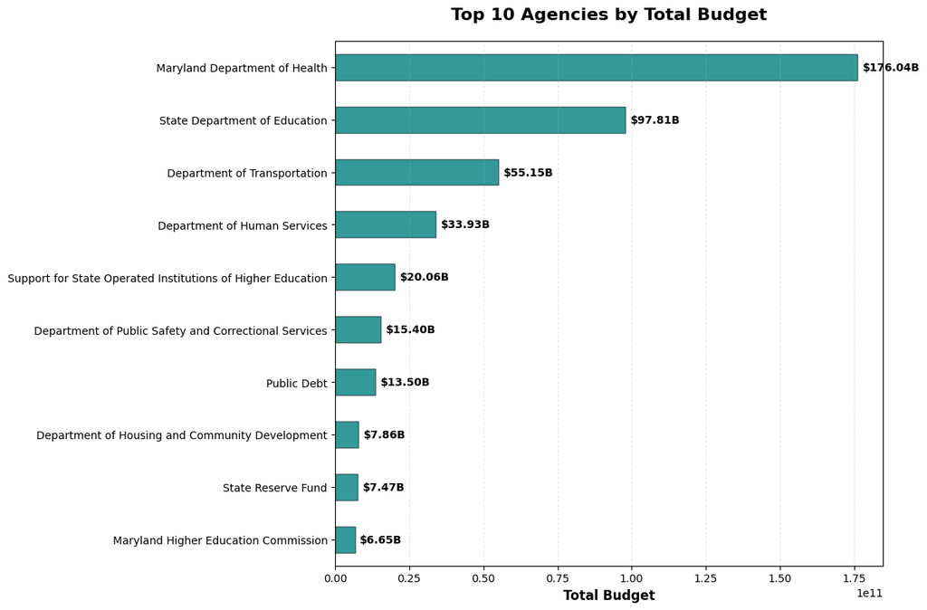

```
📊 Key Insights:
  • Total agencies in dataset: 87
  • Budget range (top 10): $6.65B to $176.04B
  • Leading agency: Maryland Department of Health
     - Budget: $176.04B
  • Top 3 agencies represent 65.3% of total budget
  • Top 10 agencies represent 86.2% of total budget

================================================================================
```

```python
# Top Agencies by Budget
print("Top 10 Agencies by Total Budget:\n")
top_agencies = df.groupby('agency_name')['budget'].sum().sort_values(ascending=False).head(10)

for i, (agency, budget) in enumerate(top_agencies.items(), 1):
    print(f"  {i:2d}. {agency:<50} {format_currency(budget):>10}")

# Plot top agencies
fig, ax = plt.subplots(figsize=(12, 8))
top_agencies.plot(kind='barh', ax=ax, color='teal', edgecolor='darkslategray', alpha=0.8)
ax.set_title('Top 10 Agencies by Total Budget', fontsize=16, fontweight='bold', pad=20)
ax.set_xlabel('Total Budget', fontsize=12, fontweight='bold')
ax.set_ylabel('')
ax.invert_yaxis()
ax.grid(axis='x', alpha=0.3, linestyle='--')

# Add value labels on bars
for i, v in enumerate(top_agencies):
    ax.text(v + max(top_agencies)*0.01, i, format_currency(v), va='center', fontsize=10, fontweight='bold')

plt.tight_layout()
plt.show()

# Calculate insights
total_all_agencies = df.groupby('agency_name')['budget'].sum().sum()
top_10_total = top_agencies.sum()
top_3_total = top_agencies.head(3).sum()

print("\n📊 Key Insights:")
print(f"  • Total agencies in dataset: {df['agency_name'].nunique()}")
print(f"  • Budget range (top 10): {format_currency(top_agencies.min())} to {format_currency(top_agencies.max())}")
print(f"  • Leading agency: {top_agencies.index[0]}")
print(f"     - Budget: {format_currency(top_agencies.iloc[0])}")
print(f"  • Top 3 agencies represent {(top_3_total / total_all_agencies * 100):.1f}% of total budget")
print(f"  • Top 10 agencies represent {(top_10_total / total_all_agencies * 100):.1f}% of total budget")

print("\n" + "="*80)
```

## 5. Agency Analysis

### 5.1 Top Agencies by Budget

```
Top 10 Fund Sources by Total Budget:

   1. General Funds                                        $220.79B
   2. Medical Assistance Program                            $90.12B
   3. Transportation Trust Fund                             $41.76B
   4. Supplemental Nutrition Assistance Program             $16.40B
   5. Annuity Bond Fund                                     $10.28B
   6. The Blueprint for Maryland's Future Fund               $8.31B
   7. Highway Planning and Construction                      $6.70B
   8. American Rescue Plan Act of 2021                       $4.20B
   9. Disaster Grants - Public Assistance                    $3.71B
  10. Children's Health Insurance Program                    $3.35B

Total Distinct Fund Sources: 1206
```

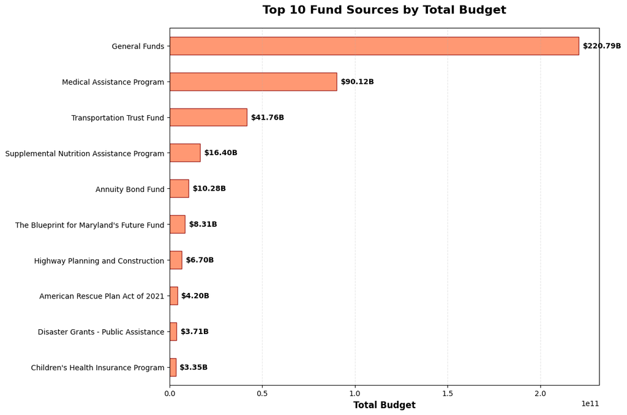

[output not shown]

```python
# Top Fund Sources by Budget
print("Top 10 Fund Sources by Total Budget:\n")
top_funds = df.groupby('fund_source_name')['budget'].sum().sort_values(ascending=False).head(10)

for i, (fund, budget) in enumerate(top_funds.items(), 1):
    print(f"  {i:2d}. {fund:<50} {format_currency(budget):>10}")

print(f"\nTotal Distinct Fund Sources: {df['fund_source_name'].nunique()}")

# Plot top fund sources
fig, ax = plt.subplots(figsize=(12, 8))
top_funds.plot(kind='barh', ax=ax, color='coral', edgecolor='darkred', alpha=0.8)
ax.set_title('Top 10 Fund Sources by Total Budget', fontsize=16, fontweight='bold', pad=20)
ax.set_xlabel('Total Budget', fontsize=12, fontweight='bold')
ax.set_ylabel('')
ax.invert_yaxis()
ax.grid(axis='x', alpha=0.3, linestyle='--')

# Add value labels on bars
for i, v in enumerate(top_funds):
    ax.text(v + max(top_funds)*0.01, i, format_currency(v), va='center', fontsize=10, fontweight='bold')

plt.tight_layout()
plt.show()

# Calculate insights
total_all_funds = df.groupby('fund_source_name')['budget'].sum().sum()
top_3_funds = top_funds.head(3).sum()

print("\n📊 Key Insights:")
print(f"  • Total distinct fund sources: {df['fund_source_name'].nunique()}")
print(f"  • Leading fund source: {top_funds.idxmax()}")
print(f"     - Budget: {format_currency(top_funds.max())}")
print(f"  • Top 3 sources represent {(top_3_funds / total_all_funds * 100):.1f}% of total funding")
print(f"  • Budget concentration: Top 10 sources account for {(top_funds.sum() / total_all_funds * 100):.1f}% of all funding")

print("\n" + "="*80)
```

## 6. Funding Source Analysis

### 6.1 Top Fund Sources

```
Budget Summary by Fund Type:
```

```
Fund Type                         Total Budget    Records      Avg Budget
------------------------------------------------------------------------
General Funds                         $220.79B      4,405         $50.12M
Federal Funds                         $161.54B      9,190         $17.58M
Special Funds                         $105.92B      9,210         $11.50M
American Rescue Plan Act of 21          $8.64B        535         $16.15M
Coronavirus Aid, Relief, and Economic Security Act          $2.59B        198         $13.10M
Coronavirus Response & Relief Sup Act          $2.49B        121         $20.55M
Federal Funds (COVID)                   $1.56B         36         $43.33M
Federal Funds (ARRA)                    $2.84M          3        $945.45K
```

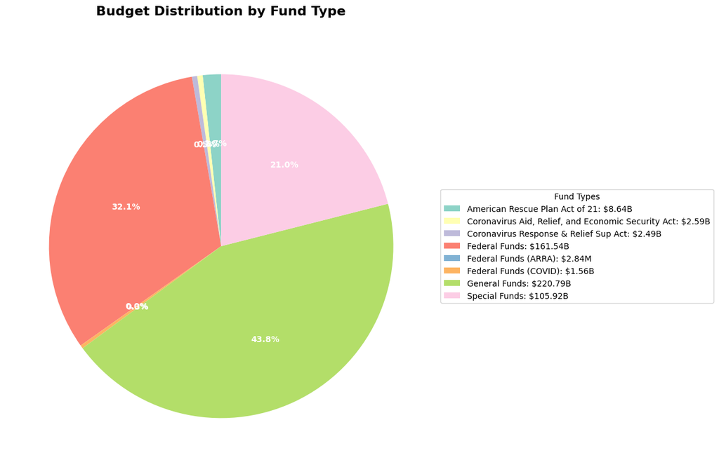

```
📊 Key Insights:
  • Number of fund types: 8
  • Largest fund type: General Funds
     - Total: $220.79B
     - Share: 43.8% of total budget
  • Highest average budget per record: General Funds ($50.12M)

================================================================================
```

```python
# Budget by Fund Type
print("Budget Summary by Fund Type:\n")
fund_type_budget = df.groupby('fund_type_name')['budget'].agg(['sum', 'count', 'mean']).sort_values('sum', ascending=False)

print(f"{'Fund Type':<30} {'Total Budget':>15} {'Records':>10} {'Avg Budget':>15}")
print("-" * 72)
for fund_type, row in fund_type_budget.iterrows():
    print(f"{fund_type:<30} {format_currency(row['sum']):>15} {int(row['count']):>10,} {format_currency(row['mean']):>15}")

# Pie chart with legend
fig, ax = plt.subplots(figsize=(14, 8))
fund_type_totals = df.groupby('fund_type_name')['budget'].sum()
colors = plt.cm.Set3(range(len(fund_type_totals)))

# Create pie chart with percentage labels
wedges, texts, autotexts = ax.pie(fund_type_totals, autopct='%1.1f%%',
                                    startangle=90, colors=colors,
                                    textprops={'fontsize': 10, 'fontweight': 'bold'})

# Make percentage text white for better contrast
for autotext in autotexts:
    autotext.set_color('white')

# Create legend with fund type names and amounts
legend_labels = [f"{name}: {format_currency(amount)}"
                 for name, amount in fund_type_totals.items()]
ax.legend(wedges, legend_labels, title="Fund Types",
          loc="center left", bbox_to_anchor=(1, 0, 0.5, 1), fontsize=10)

ax.set_title('Budget Distribution by Fund Type', fontsize=16, fontweight='bold', pad=20)
plt.tight_layout()
plt.show()

print("\n📊 Key Insights:")
print(f"  • Number of fund types: {len(fund_type_totals)}")
print(f"  • Largest fund type: {fund_type_totals.idxmax()}")
print(f"     - Total: {format_currency(fund_type_totals.max())}")
print(f"     - Share: {(fund_type_totals.max() / fund_type_totals.sum() * 100):.1f}% of total budget")
print(f"  • Highest average budget per record: {fund_type_budget['mean'].idxmax()} ({format_currency(fund_type_budget['mean'].max())})")

print("\n" + "="*80)
```

### 6.2 Fund Type Distribution

```
Analyzing budget trends for top 5 agencies across fiscal years...

Top 5 Agencies:
  1. Maryland Department of Health - $176.04B
  2. State Department of Education - $97.81B
  3. Department of Transportation - $55.15B
  4. Department of Human Services - $33.93B
  5. Support for State Operated Institutions of Higher Education - $20.06B
```

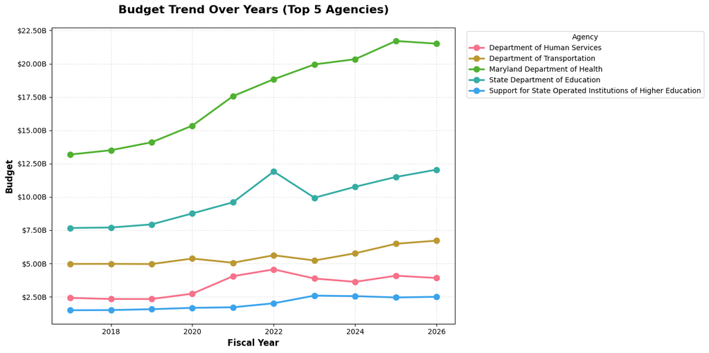

```
📊 Key Insights:
  • Maryland Department of Health:
     - Increased by 63.2% from FY2017 to FY2026
     - From $13.18B to $21.51B
  • State Department of Education:
     - Increased by 57.1% from FY2017 to FY2026
     - From $7.67B to $12.05B
  • Department of Transportation:
     - Increased by 35.2% from FY2017 to FY2026
     - From $4.97B to $6.72B

================================================================================
```

```python
# Budget Trend Over Years by Top Agencies
print("Analyzing budget trends for top 5 agencies across fiscal years...\n")

top_5_agencies = df.groupby('agency_name')['budget'].sum().nlargest(5).index
print("Top 5 Agencies:")
for i, agency in enumerate(top_5_agencies, 1):
    total = df[df['agency_name'] == agency]['budget'].sum()
    print(f"  {i}. {agency} - {format_currency(total)}")

df_top_agencies = df[df['agency_name'].isin(top_5_agencies)]

pivot_data = df_top_agencies.pivot_table(
    values='budget',
    index='fiscal_year',
    columns='agency_name',
    aggfunc='sum'
)

fig, ax = plt.subplots(figsize=(14, 7))
for column in pivot_data.columns:
    ax.plot(pivot_data.index, pivot_data[column], marker='o', linewidth=2.5, markersize=8, label=column)

ax.set_title('Budget Trend Over Years (Top 5 Agencies)', fontsize=16, fontweight='bold', pad=20)
ax.set_xlabel('Fiscal Year', fontsize=12, fontweight='bold')
ax.set_ylabel('Budget', fontsize=12, fontweight='bold')
ax.legend(title='Agency', bbox_to_anchor=(1.02, 1), loc='upper left', fontsize=10)
ax.grid(True, alpha=0.3, linestyle='--')

# Format y-axis with readable currency
ax.yaxis.set_major_formatter(plt.FuncFormatter(lambda x, p: format_currency(x)))

plt.tight_layout()
plt.show()

print("\n📊 Key Insights:")
for agency in top_5_agencies[:3]:  # Show insights for top 3
    agency_data = pivot_data[agency].dropna()
    if len(agency_data) > 1:
        first_val = agency_data.iloc[0]
        last_val = agency_data.iloc[-1]
        change_pct = ((last_val - first_val) / first_val) * 100
        trend = "increased" if change_pct > 0 else "decreased"
        print(f"  • {agency}:")
        print(f"     - {trend.capitalize()} by {abs(change_pct):.1f}% from FY{int(agency_data.index[0])} to FY{int(agency_data.index[-1])}")
        print(f"     - From {format_currency(first_val)} to {format_currency(last_val)}")

print("\n" + "="*80)
```

## 7. Trend Analysis

### 7.1 Budget Trends Over Time (Top 5 Agencies)

```
Budget Categories (Total: 12 unique categories)

Top 15 Categories by Total Budget:

   1. Health                                               $181.14B
   2. Elementary and Secondary Education                    $99.32B
   3. Transportation                                        $55.15B
   4. Human Services                                        $41.97B
   5. Public Safety                                         $28.74B
   6. Higher Education                                      $27.03B
   7. Other                                                 $21.70B
   8. Public Debt                                           $13.50B
   9. Natural Resources and Environment                     $12.60B
  10. Legislative, Judicial, Legal                           $9.80B
  11. Reserve Fund                                           $7.47B
  12. Government Services                                    $5.11B
```

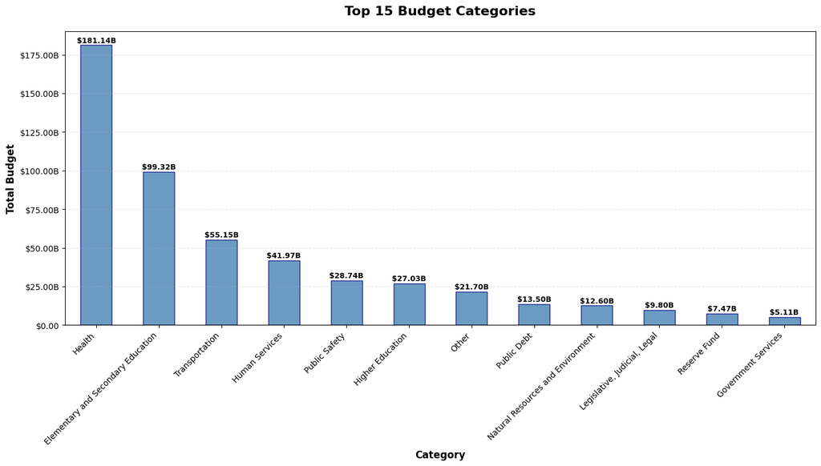

```
📊 Key Insights:
  • Total categories: 12
  • Leading category: Health
     - Budget: $181.14B
  • Top 3 categories represent 66.7% of total budget
  • Top 5 categories represent 80.7% of total budget
  • Budget concentration: 100.0% in top 15 categories

================================================================================
```

```python
# Category Analysis (Top 15)
print(f"Budget Categories (Total: {df['category_title'].nunique()} unique categories)\n")
print("Top 15 Categories by Total Budget:\n")

category_totals = df.groupby('category_title')['budget'].sum().sort_values(ascending=False)

for i, (category, budget) in enumerate(category_totals.head(15).items(), 1):
    print(f"  {i:2d}. {category:<50} {format_currency(budget):>10}")

# Plot
fig, ax = plt.subplots(figsize=(14, 8))
category_totals.head(15).plot(kind='bar', ax=ax, color='steelblue', edgecolor='navy', alpha=0.8)
ax.set_title('Top 15 Budget Categories', fontsize=16, fontweight='bold', pad=20)
ax.set_ylabel('Total Budget', fontsize=12, fontweight='bold')
ax.set_xlabel('Category', fontsize=12, fontweight='bold')
ax.grid(axis='y', alpha=0.3, linestyle='--')
plt.xticks(rotation=45, ha='right')

# Add value labels
for i, v in enumerate(category_totals.head(15)):
    ax.text(i, v + max(category_totals.head(15))*0.01, format_currency(v),
            ha='center', fontsize=9, fontweight='bold', rotation=0)

# Format y-axis
ax.yaxis.set_major_formatter(plt.FuncFormatter(lambda x, p: format_currency(x)))

plt.tight_layout()
plt.show()

# Calculate insights
total_all_categories = category_totals.sum()
top_3_categories = category_totals.head(3).sum()
top_5_categories = category_totals.head(5).sum()

print("\n📊 Key Insights:")
print(f"  • Total categories: {df['category_title'].nunique()}")
print(f"  • Leading category: {category_totals.idxmax()}")
print(f"     - Budget: {format_currency(category_totals.max())}")
print(f"  • Top 3 categories represent {(top_3_categories / total_all_categories * 100):.1f}% of total budget")
print(f"  • Top 5 categories represent {(top_5_categories / total_all_categories * 100):.1f}% of total budget")
print(f"  • Budget concentration: {(category_totals.head(15).sum() / total_all_categories * 100):.1f}% in top 15 categories")

print("\n" + "="*80)
```

## 9. Additional Data Exploration

### 9.1 Categorical Variables Summary

Overview of categorical variables and their unique values.

```python
# Categorical Summary
print("Categorical Variables Overview:\n")
print("=" * 80)

categorical_cols = df.select_dtypes(include=['object']).columns

for col in categorical_cols:
    unique_count = df[col].nunique()
    print(f"\n📋 {col.upper().replace('_', ' ')}")
    print(f"   Unique Values: {unique_count:,}")

    if unique_count <= 10:
        print(f"   All Values:")
        for val, count in df[col].value_counts().items():
            print(f"      • {val}: {count:,} records")
    else:
        print(f"   Top 5 Most Common:")
        for val, count in df[col].value_counts().head(5).items():
            print(f"      • {val}: {count:,} records ({count/len(df)*100:.1f}%)")

print("\n" + "=" * 80)
```

```
Categorical Variables Overview:

================================================================================

📋 AGENCY NAME
   Unique Values: 87
   Top 5 Most Common:
      • Department of Natural Resources: 3,028 records (12.8%)
      • Maryland Department of Health: 2,966 records (12.5%)
      • State Department of Education: 1,876 records (7.9%)
      • Department of Human Services: 1,816 records (7.7%)
      • Maryland Department of Labor: 1,594 records (6.7%)

📋 PROGRAM NAME
   Unique Values: 679
   Top 5 Most Common:
      • General Administration: 1,065 records (4.5%)
      • Executive Direction: 488 records (2.1%)
      • Community Services: 455 records (1.9%)
      • Finance and Administrative Services: 410 records (1.7%)
      • Information Technology Service: 391 records (1.6%)

📋 UNIT NAME
   Unique Values: 214
   Top 5 Most Common:
      • Office of the Secretary: 3,992 records (16.8%)
      • State Department of Education - Headquarters: 1,200 records (5.1%)
      • Local Department Operations: 722 records (3.0%)
      • Prevention and Health Promotion Administration: 711 records (3.0%)
      • Aid To Education: 563 records (2.4%)

📋 CATEGORY TITLE
   Unique Values: 12
   Top 5 Most Common:
      • Natural Resources and Environment: 5,158 records (21.8%)
      • Other: 5,015 records (21.2%)
      • Health: 3,553 records (15.0%)
      • Human Services: 2,983 records (12.6%)
      • Elementary and Secondary Education: 2,005 records (8.5%)

```

[output cut: 84 more lines]

```
      • Medical Assistance Program: 355 records (1.5%)
      • Transportation Trust Fund: 284 records (1.2%)
      • American Rescue Plan Act of 2021: 254 records (1.1%)
      • Inmate Welfare Funds: 209 records (0.9%)

📋 DESCRIPTION
   Unique Values: 921
   Top 5 Most Common:
      • The Secretariat program provides overall direction and supervision of the Department.: 375 records (1.6%)
      • The Prevention and Health Promotion Administration (PHPA) protects, promotes, and improves the health and well-being of all Marylanders through partnerships with local health departments and public and private sector agencies through efforts focusing in part on the prevention and control of …
      • The Family Health and Chronic Disease Services Program of the Prevention and Health Promotion Administration seeks to assure the availability of quality health services to the citizens of Maryland, with special emphasis on women, children and their families. The Program includes the Office o…
      • The Finance and Administrative Services program handles all financial transactions and provides centralized support services for the Department including procurement, fleet management, mail services, and facilities support.: 286 records (1.2%)
      • The Information Technology Service provides system and network engineering services and equipment, technical support services, and operation of the Department’s network of computing resources.: 269 records (1.1%)

================================================================================
```

```
Budget Breakdown: Top 5 Agencies Across Fiscal Years

Selected Agencies:
  1. Maryland Department of Health
  2. State Department of Education
  3. Department of Transportation
  4. Department of Human Services
  5. Support for State Operated Institutions of Higher Education

📊 Budget Pivot Table (in billions):

fiscal_year                                                    2017    2018    2019    2020    2021    2022    2023    2024    2025    2026
agency_name
Department of Human Services                                  2.42B   2.34B   2.34B   2.73B   4.05B   4.56B   3.87B   3.62B   4.08B   3.91B
Department of Transportation                                  4.97B   4.97B   4.96B   5.37B   5.06B   5.62B   5.23B   5.77B   6.48B   6.72B
Maryland Department of Health                                13.18B  13.51B  14.10B  15.35B  17.57B  18.83B  19.95B  20.34B  21.71B  21.51B
State Department of Education                                 7.67B   7.70B   7.94B   8.76B   9.60B  11.91B   9.94B  10.76B  11.50B  12.05B
Support for State Operated Institutions of Higher Education   1.49B   1.50B   1.57B   1.67B   1.71B   2.01B   2.59B   2.55B   2.46B   2.50B
```

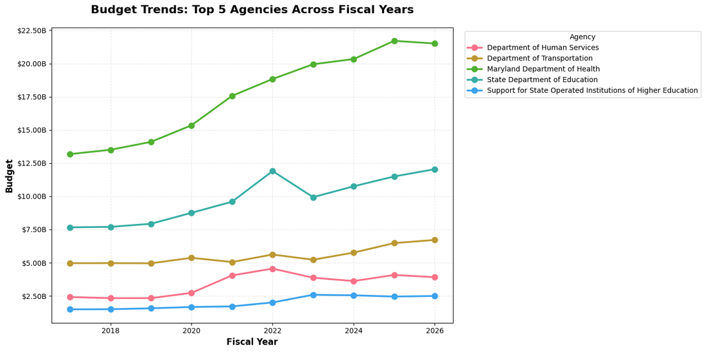

```python
# Summary Statistics by Agency and Fiscal Year
print("Budget Breakdown: Top 5 Agencies Across Fiscal Years\n")

top_5_agencies = df.groupby('agency_name')['budget'].sum().nlargest(5).index
print("Selected Agencies:")
for i, agency in enumerate(top_5_agencies, 1):
    print(f"  {i}. {agency}")

df_top = df[df['agency_name'].isin(top_5_agencies)]

summary = df_top.pivot_table(
    values='budget',
    index='agency_name',
    columns='fiscal_year',
    aggfunc='sum'
)

print("\n📊 Budget Pivot Table (in billions):\n")
# Display with formatted values
summary_display = summary.copy()
for col in summary_display.columns:
    summary_display[col] = summary_display[col].apply(lambda x: f"{x/1e9:.2f}B" if pd.notna(x) else "-")
print(summary_display.to_string())

# Visualization
fig, ax = plt.subplots(figsize=(14, 7))
for agency in summary.index:
    ax.plot(summary.columns, summary.loc[agency], marker='o', linewidth=2.5, markersize=8, label=agency)

ax.set_title('Budget Trends: Top 5 Agencies Across Fiscal Years', fontsize=16, fontweight='bold', pad=20)
ax.set_xlabel('Fiscal Year', fontsize=12, fontweight='bold')
ax.set_ylabel('Budget', fontsize=12, fontweight='bold')
ax.legend(title='Agency', bbox_to_anchor=(1.02, 1), loc='upper left', fontsize=10)
ax.grid(True, alpha=0.3, linestyle='--')

# Format y-axis
ax.yaxis.set_major_formatter(plt.FuncFormatter(lambda x, p: format_currency(x)))

plt.tight_layout()
plt.show()

print("\n" + "=" * 80)
```

## 10. Summary & Conclusions

### Key Findings

This analysis of Maryland's Operating Budget (FY2017-2026) reveals several important patterns:

**Budget Scale & Distribution:**

- Total budget spans multiple fiscal years with significant variation in allocation sizes
- Budget values range from very small allocations to multi-billion dollar agency budgets
- High concentration: A small number of agencies control the majority of budget resources

**Agency Insights:**

- Maryland Department of Health consistently leads in total budget allocation
- Top 3 agencies account for a substantial portion of total state budget
- Clear hierarchy exists in resource allocation across state agencies

**Funding Structure:**

- Multiple funding sources contribute to the operating budget
- Distinct fund types serve different governmental purposes
- Budget concentration is evident at both agency and funding source levels

**Temporal Trends:**

- Budget allocations show year-over-year variations
- Top agencies maintain relatively stable positions over time
- Some agencies show growth trends while others remain more constant

**Category Distribution:**

- Budget categories show varied allocation patterns
- Certain expenditure types dominate overall spending
- Category analysis reveals state spending priorities

### Data Quality Notes

- All budget values represent actual U.S. dollars (not millions or billions)
- Data filtered to include only records with positive budget values
- Dataset covers fiscal years 2017 through 2026
- Multiple dimensions available for analysis (agency, program, fund source, category)

### Recommended Next Steps

1. **Deeper Temporal Analysis:** Examine year-over-year growth rates and budget volatility
2. **Program-Level Analysis:** Drill down into specific programs within major agencies
3. **Comparative Analysis:** Compare Maryland's budget structure to other states
4. **Predictive Modeling:** Build forecasting models for future budget allocations
5. **Efficiency Analysis:** Assess budget efficiency and outcomes per dollar spent

**Analysis Complete** | Data Source: Maryland Department of Budget and Management